# Лабораторная работа №2

Презентация

Миличевич Александра

Российский университет дружбы народов, Москва, Россия

15 февраля 2025

# Цель работы

Познакомиться с шифрами перестановки.

# Задание

1. Программно реализовать маршрутное шифрование.
2. Программно реализовать шифрование с помощью решёток.
3. Программно реализовать шифр Виженера.

# Выполнение лабораторной работы

### Маршрутное шифроваие

1. Код сначала подготавливает текст для шифрования, заменяя пробелы на “ sp” и определяя размеры матрицы на основе длины текста и заданного ключа. Затем, символы текста последовательно записываются в матрицу по строкам, заполняя её слева направо и сверху вниз. Эта матрица используется для маршрутного шифрования.

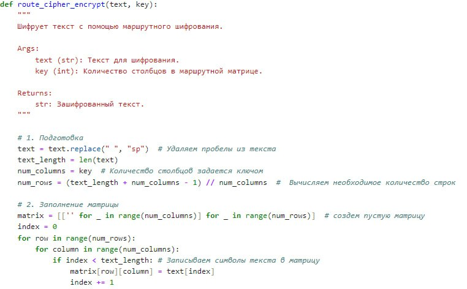

реализация маршрутного шифрования

## . Чтение матрицы по столбцам

После заполнения матрицы, код считывает ее по столбцам сверху вниз, формируя зашифрованный текст. Символы каждого столбца добавляются в общий шифрованный текст, который затем возвращается как результат работы алгоритма. Таким образом текст шифруется путем записи по строкам и чтения по столбцам.

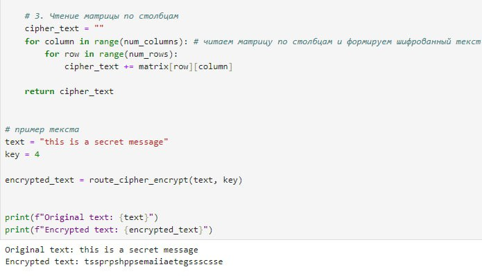

реализация маршрутного шифрования2

## Шифрование с помощью решеток

Шифрование с помощью решеток — это метод, который использует физическую решетку для замены и перемещения символов в сообщении. Этот подход позволяет создавать зашифрованные тексты, которые сложно расшифровать без знания расположения решетки и ее конфигурации. Шифрование с помощью решеток часто применяется в ситуациях, где требуется высокая степень безопасности и защита от несанкционированного доступа.

В примере, решетка (grille) задается списком кортежей, где каждый кортеж указывает строку и столбец, куда должен быть помещен соответствующий символ текста. Результат работы алгоритма — зашифрованный текст, сформированный из прочитанных по строкам элементов матрицы.

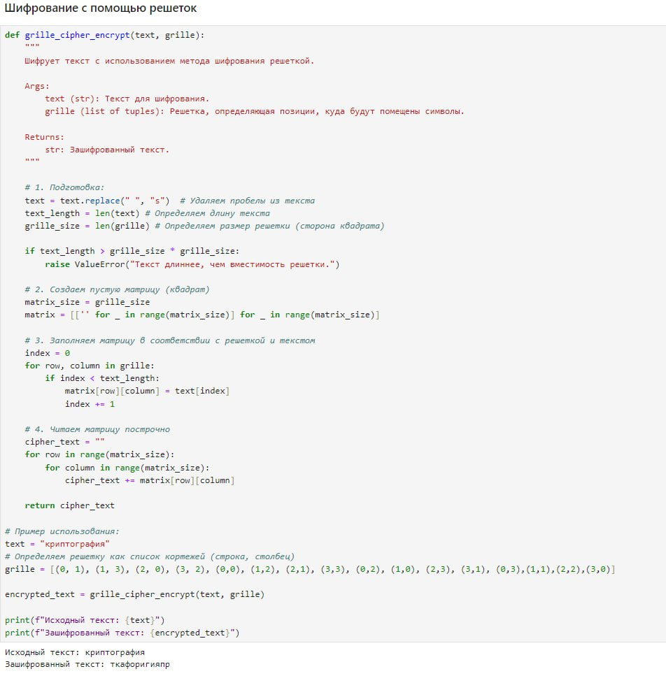

реализация шифрования с помощью решеток

## Таблица Виженера

Таблица Виженера — это метод шифрования, который использует ключевое слово для создания шифра, обеспечивая более высокий уровень безопасности по сравнению с простыми методами шифрования. В этой таблице строки и столбцы представляют буквы алфавита, а пересечения содержат зашифрованные символы, полученные путем смещения исходного текста на значение, соответствующее букве ключа. Использование таблицы Виженера позволяет избежать повторяющихся шаблонов в зашифрованном тексте, что делает его более устойчивым к криптоанализу.

Этот код реализует шифрование Виженера, где каждый символ текста сдвигается на величину, определяемую соответствующим символом ключа, повторяющегося по циклу. Функция `vigenere_cipher_encrypt` сначала приводит текст и ключ к верхнему регистру, а затем для каждой буквы текста вычисляет её сдвиг, используя соответствующую букву ключа и выполняя операцию взятия остатка от деления на 26. Результатом является шифрованный текст, где неалфавитные символы остаются неизменными. В этом конкретном примере текст “HELLO” шифруется с помощью ключа “KEY”, что приводит к зашифрованному тексту, где буквы сдвигаются на величину, задаваемую буквами ключа. Разница между шифрованием Виженера и другими шифрами, например, маршрутным или решеточным, заключается в том, что Виженер использует полиалфавитный шифр с циклическим ключом, в то время как маршрутный и решеточный шифры используют перестановку символов.

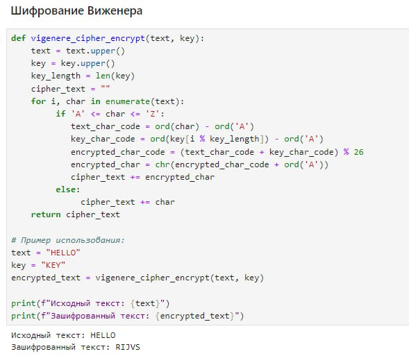

реализация шифрования таблица Виженера

В коде для шифрования Виженера на русском языке добавлен русский алфавит (`alphabet_ru`) и его длина (`alphabet_length`), чтобы обрабатывать символы русского языка. Индексы букв берутся из русского алфавита с помощью `alphabet_ru.find()`, и для шифрования используется модуль от деления на длину русского алфавита. Если символ не найден в русском алфавите, он добавляется в зашифрованный текст без изменений.

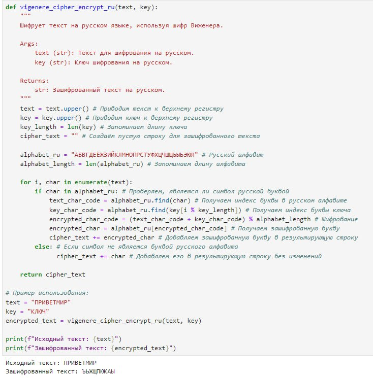

с русским алфавитом таблица Виженера

# Выводы

Программно реализованы шифры перестановки.